# Data Camp Insights

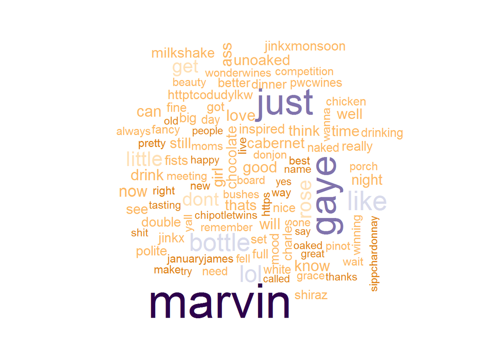

```r
# Create purple_orange
purple_orange <- brewer.pal(10, "PuOr")

# Drop 2 faintest colors
purple_orange <- purple_orange[-(1:2)]

# Create a wordcloud with purple_orange palette
wordcloud(chardonnay_freqs$term, chardonnay_freqs$num, max.words = 100, colors = purple_orange)
```

```r
# NEED TO IMPORT THE TWEET DATA FROM RAW DATA
# Create all_coffee
all_coffee <- paste(coffee_tweets, collapse=" ")

# Create all_chardonnay
# all_chardonnay <- paste(chardonnay_tweets$text, collapse=" ")

# Create all_tweets
# all_tweets <- c(all_coffee, all_chardonnay)

# Convert to a vector source
# all_tweets <- VectorSource(all_tweets)

# Create all_corpus
# all_corpus <- VCorpus(all_tweets)


clean_corpus <- function(corpus){
  corpus <- tm_map(corpus, removePunctuation)
  corpus <- tm_map(corpus, stripWhitespace)
  corpus <- tm_map(corpus, removeNumbers)
  corpus <- tm_map(corpus, content_transformer(tolower))
  corpus <- tm_map(corpus, removeWords, c(stopwords("en"), "amp", "glass", "chardonnay", "coffee"))
  return(corpus)
}

# Clean the corpus
# all_clean <- clean_corpus(all_corpus)

# Create all_tdm
# all_tdm <- TermDocumentMatrix(all_clean)

# Create all_m
# all_m <- as.matrix(all_tdm)

# Print a commonality cloud
# commonality.cloud(all_m, colors="steelblue1", max.words=100)


# Clean the corpus
# all_clean <- clean_corpus(all_corpus)

# Create all_tdm
# all_tdm <- TermDocumentMatrix(all_clean)

# Give the columns distinct names
# colnames(all_tdm) <- c("coffee", "chardonnay")

# Create all_m
# all_m <- as.matrix(all_tdm)

# Create comparison cloud
# comparison.cloud(all_m, colors=c("orange", "blue"), max.words=50)


# Create common_words
# common_words <- subset(all_tdm_m, all_tdm_m[, 1] > 0 & all_tdm_m[, 2] > 0)

# Create difference
# difference <- abs(common_words[, 1] - common_words[, 2])

# Combine common_words and difference
# common_words <- cbind(common_words, difference)

# Order the data frame from most differences to least
# common_words <- common_words[order(common_words[, 3], decreasing = TRUE), ]

# Create top25_df
# top25_df <- data.frame(x = common_words[1:25, 1],
#                        y = common_words[1:25, 2],
#                        labels = rownames(common_words[1:25, ]))

# Create the pyramid plot
# pyramid.plot(top25_df$x, top25_df$y, labels=top25_df$labels,
#              gap=8, top.labels = c("Chardonnay", "Words", "Coffee"),
#              main = "Words in Common", laxlab = NULL,
#              raxlab = NULL, unit = NULL
#              )


# Word association
word_associate(coffee_tweets, match.string = c("barista"),
               stopwords = c(Top200Words, "coffee", "amp"),
               network.plot = TRUE, cloud.colors = c("gray85", "darkred"))
```

```
##   row group unit text
## 1 544   all  544 RT @Barista_kyo: #coffee #latte #soylatte #thinkcoffee # # # # @ think coffee http://t.co/Hmy9RPRWTZ
## 2 569   all  569 RT @ReversoSmith: What a beautiful mess! #portafilter #coffee #espresso #coffeemachine #barista #baristalife? http://t.co/ZODcTfP22Z
## 3 658   all  658 The moment you realize your Starbucks barista gave you a regular iced Coffee when u asked 4 decaf. Shitty. Late night not planned.
## 4 931   all  931 Barista made my coffee wrong and still gave me both anyway #Starbucks #coffee #caffeine #upallnight http://t.co/iKCNwO8F6t
## 5 951   all  951 RT @FrankIero: hahaha @jamiasan :*gives Barista our Starbucks order* Barista: coffee? @jamiasan : yes, isn't this is a coffee store?
```

```
##
## Match Terms
## ===========
```

```
##
## List 1:
## baristakyo, barista, baristalife
```

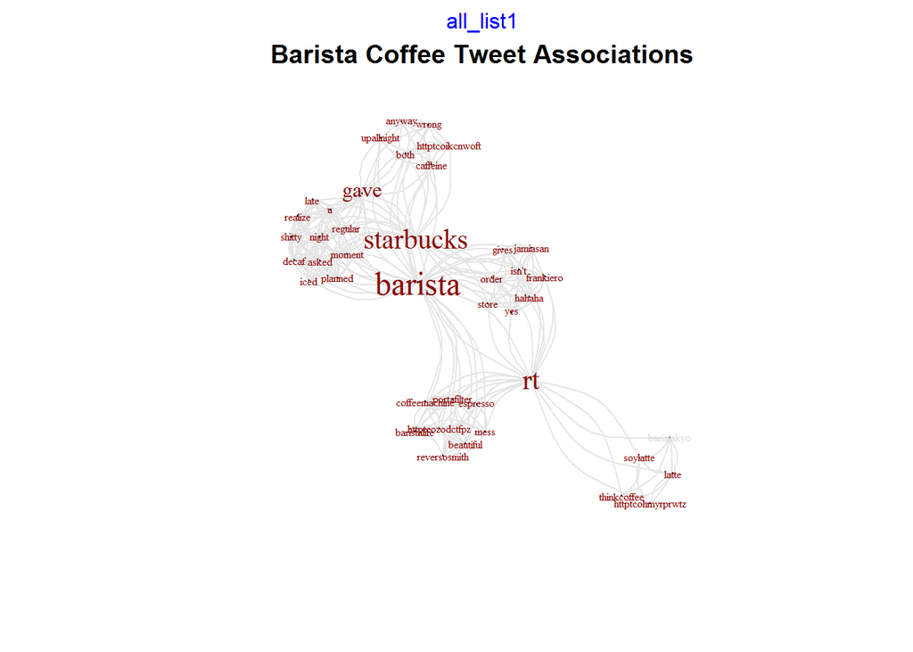

```r
# Add title
title(main = "Barista Coffee Tweet Associations")
```

Chapter 3 - Additional text matching (library tm) skills

## R Markdown and RStudio

### *RStudio IDE (Part I)*

##### *Chapter 1 - Orientation*

R is a programming language, while RStudio is a company that created an IDE for R:

- The IDE works alongside the R interpreter, with many extenders and simplifications - arsenal
- Multiple versions - free desktop, free server, professional network

Install R and Rstudio - both are free downloads:

- R - download from CRAN (select the “base” version from within Windows)
- Rstudio - download from www.rstudio.com (grab the installer, then install)

Rstudio panes - Console, Environment, File/Plot/Package/Help:

- Upon opening the first file, the Console (LHS) pane shrinks to lower-left, with the Source pane then in the upper-left
- Tools/Global Options/Layout allows for adjusting the contents of the key panes
- Console is what you would see in pure R
  - Ctrl-L will clear the console window
  - Up-arrow will go back to most recent commands
  - Ctrl-Up will search for recent commands similar to what you are typing
  - Tab (automatic after three characters have been typed) will pop-up the functions, objects, and datasets that bein with what you have typed
  - Tab (inside a single bracket) will show the options available for filtering - DOES NOT SEEM TO WORK
- Tools/Global Options/Code/Completion can change the behavior of the tab key and other shortcuts

Source pane - good place to write multi-line code prior to running it in the console:

- Can open many languages in the source pane, including R, C++, Python, SQL, etc.
  - Rstudio will understand each of these languages based on the file extension applied
  - File/New File/Text opens a generic text editor
- Ctrl-Enter will run the code that is currently selected in the Source pane (if nothing selected, the line the cursor is currently on)
- Cltrl-Shift-S will run everything in the Source pane
  - Ctrl-Shift-Enter (or the drop-down for Source/Source with Echo) will print the results to the screen
- Ctrl+1 will move to the Source pane, while Ctrl+2 will move to the Console pane

The View() function is the data viewer - just run it at the console, with the name of a frame inside:

- The tab appears in the Source pane, though you can blow it out with the “show in new window” button

Environment pane is in the upper-right corner, keeping track of the R session:

- Includes Environment tab with the objects that have been created during the R session
  - Can also select to view objects in other environments using the associated drop-down
  - Clicking on the logo at the right of a function will pop-up the full function
  - Clicking the disk will save an environment as a .Rdata environment
  - Can also use “Import Dataset” from the environment tab to preview how the data-load will look (like the Excel Wizard in a way)

History tab is next to the environment tab, as part of the Environment pane:

- Can clear with broom or save as an R History file
- Can click on an item and then click “To Console” to get it to the console
- Can hit Shift-Enter to put the command to the active tab of the Source pane

Files pane is in the bottom-right corner of the default Rstudio layout:

- Shows the contents of the current working directory (somewhat like the Windows Explorer)
- Can use the More drop-down to set the working directory (nice!)

Plots pane and packages tab - the lower-right series of panes:

- Can open plots in their own windows using the Zoom icon
- Can save the file using the Export icon (preview window allows for setting parameters for the saved file)
- The packages tab provides an easy way to see which packages you currently have available in R, as well as their versions
  - Can click or un-click a package to load (library) or unload (detach) the package
  - Can further use the GUI for installing and/or updating packages

Help pane displays the help pages for R objects:

- Can type help(Robject) or ?Robject on the control line
- Can highlight object in Source or Console pane and then clicking F1

Viewer tab is also in the lower-right pane, and shows html output (if any) produced during the session:

- Useful for Rmarkdown objects, Shiny objects, and the like

##### *Chapter 2 - Programming*

Coding features - when writing in the Source pane for a .R object in Rstudio, R-specific coding and extensions are applied:

- If saved as .html or .cpp, then the coloring and completions would be specific to these languages
  - Also has Python, SQL, etc.
- Can go to Tools/Global Options/Code/Completion to make edits

Coding diagnostics - Rstudio flags potential errors in the code prior to the code running:

- Yellow caution box for issues like variable not in scope
- Syntax errors, unmatched brackets, and the like, will be marked with a red X (error)
- Helps to keep code formatted to adv-r.had.co.nz/Style.html (can turn on this option in Tools / Global Options / Code / Diagnostics / R-style-diagnostics)
- Messages appear only when 1) stopping writing for 2+ seconds, or 2) immediately after saving

Keyboard shortcuts help save time while writing code in the Source pane:

- CTRL-SHIFT-M will create the symbol for the pipe operator %>% from the magrittr package
- ALT/+/- will create the assignment operator
- CTRL-SHIFT-C will block comment/uncomment all the selected lines
- CTRL-SHIFT-/ will reflow a comment, which is to say put the comment on multiple lines for easier readability / fitting the screen
- Can find all of the shortcuts in Tools/Keyboard Shortcuts Help (ALT-SHIFT-K) - can close this using Esc
- Can also use code snippets to help with very common code-writing activities
  - Will pop up when typing the first few letter, such as “fun” to get the functions snippet
  - Can edit these in Tools/Global Options/Code/Snippets (available for many languages, not just R)
- Can use “Extract Function” to have Rstudio wrap the function(){ } around the selected line(s) of code

Multiple cursors can be created within the editor using CTRL-ALT-:

- Everything you type will happen at all of the cursors
- Clicking anywhere in the document with the mouse will then bring back single-cursor mode
- Can also choose Tools/Global Options/Code/Enable vim (to enable vim-like capability in Rstudio)

Navigate and edit code using SHIFT-ALT-G to jump to any line in the document:

- CTRL-F opens the Find or Find/Replace capability
- ALT-O will close all of the folds (more or less hide the lines of the functions, loops, and the like)
- CTRL+P will allow for moving back/forth between the paired parentheses or brackets

Run scripts frequently to help with checking and debugging code:

- CTRL-ENTER and CTRL-SHIFT-ENTER can be used with C++, Python, and R Script
- CTRL-SHIFT-F10 ensures that there are no “stray” objects and that code is really running OK on a stand-alone basis

Traceback helps to debug errors that occur when you run the code:

- Rstudio throws the error message and shows 1) the function with the error, and 2) the traceback leading up to that error-function
- Default is for Rstudio to show the traceback if there were 2+ functions in the call that led to the error
- Can also access debugger mode using “Run with Debug” in the Rstudio error message

Debugger mode is a way of pausing time - run one line, then see how Rstudio sees the code and environment and variables at that specific moment:

- Can click the check-box for “Show Internals” to see the R internal functions called, though this is often of very limited use/need
- The highlighted line of code is always the NEXT line of code that will be run
- Can also use the command line to play around while the code is stopped - will be shown as Browse[1]> rather than just > to signal that you are currently in debugger
- Continue/Stop will return you to normal mode and close out the debugger, as will capital-q (Q) typed at the Browse[1]> command line

Debugger mode: breakpoints can help find what is going wrong, even if the code is not throwing a formal error (wrong result, rather than code bombs out):

- Debug has the breakpoints commands; can set the breakpoints as needed, and R will enter debugger mode (and stop running)
- Any call to browser() in the script will enter the debugger mode at the specific point
- Can also use the debugonce() command to access a function???
  - This will set a one-time-only breakpoint, and debugonce() will need to be called again if you want to use it again
- By contrast, debug() will put a permanent breakpoint at the top of the function
  - Can use undebug() to get rid of the permanent breakpoint
- If the command options(error=browser) has been set, then every error will enter the debugger mode automatically
  - Can use options(error=NULL) to restore the R default behavior
- If the function is in debgugger mode, can run single lines of code at a time using the Next command

##### *Chapter 3 - Projects*

Rstudio project for navigating between projects:

- When projects are closed in Rstudio, the files, environments, and the like are remebered for later
- Each project can be assigned its own working directory also
- File/New Project will ask for a directory; this will become the working directory any time you open this project
  - New Directory (choices of Empty Project, R Package, or Shiny Application) - if Project, can choose packrat and/or .git and/or new window
  - Existing Directory
  - Version Control - Git or the like

Populating projects - assuming starting with File/New Project/New Directory/Empty Project:

- Project name is in the upper-right of the IDE
- The .rproj file stores the current status of the history, source pane, and the like
- File/Open Project in New Session will open a new Rstudio IDE that runs independently of existing Rstudio IDE
- Will still have the most recent commands available in the workspace, along with any objects when it was last saved
- CTRL-SHIFT-F or CTRL-. Can help find files containing a specified piece of text (could be quite useful)

Packrat allows for using different versions of a package for different projects (useful for reproducible research):

- Available at rstudio.packrat.io
- Packrat allows for associating each project with its own versions of a package
- When the project is opened on a new computer, Packrat downloads and installs the relevant packages/versions to match up with that project
  - Added benefit of reproducibility; code should continue to work, and to produce the same results, even if packages have changed or deprecated in the interim
- File/New Project/Empty Project and check the “use packrat” box will associate the new, empty project with packrat
- Tools/Project Options/Packrat can associate packrat to an existing project (generally recommended to stay with the defaults)
- The “packrat” folder within the project will contain the source code for all the associated R projects, allowing for the package library to be in its previous state
- Can also run at the command line - visit rstudio.github.io/packrat for more details about packrat

### *RStudio IDE (Part II)*

##### *Chapter 1 - Packages*

Introduction to R packages - best way to share functions, vignettes, and the like:

- Includes at a minimum 1) writing R functions, 2) documenting R functions, 3) testing R functions, 4) verifying compatibility, and 5) ease of sharing/use
- Wickham has written a book “R Packages” which can help with writing R packages
- File/New Project/New Directory/R Package will create a new directory specific for the package
  - Includes two key files, NAMESPACE (list of functions that will be made available to users; generated automatically) and DESCRIPTION (meta description about the package; needs to be edited)
  - Includes an R directory for code and a man directory for the help manual (?function)
  - Further, a “Build” tab is included in the Environment/History area

Import and load source files - can add files from the “Add” tab of the File/New Project/New Directory/R Package process:

- Generally, each of the .R files in the R directory is generally a single function
- The “Build” tab in the Environment/History pane allows for “More/Load All” to bring in all the .R files in the package directory at the same time
  - Functions do NOT appear in the environment; it is instead much more like calling library() where the functions are available but not in the environment
  - Can also be called by way of CTRL-SHIFT-L
  - Can also use CTRL-SHIFT-F10 to be sure that you have a brand new R session prior to testing all the functions in the package

Package documentation (Part I) - R documentation files have a special format and are saved as .Rd files:

- Rstudio uses the “roxygen2” package to help keep the functions (.R) and documentation/help (.Rd) synchornized
- This places the help pages and the functions in the same editing pane
- Tools/Project Options/Build Tools/“Generate documentation with roxygen”
- Within the function, type CTRL-ALT-SHIFT-R to being in the roxygen editing template (skeleton) at the top of the function
  - The combination of #’ at the start of the line signals to roxygen that this is code for itself (it is a comment to the function also due to the #)

Package documentation (Part II) - filling in the skeleton that roxygen has created:

- Type the function name in the very first line
- Then, leave a blank line
- Then type in a simple description of the function (note that leaving a blank line signals to roxygen to consider the next portion to be a new paragraph)
  - CTRL-SHIFT-/ can re-flow the oxygen comments if they have become too long for a single screen
- The roxygen tags will all be preceded by the @ symbol
  - There can be multiple parameters, each flagged as #’ @param
  - The #’ @return section should describe what the function will return
  - The #’ @export section signifies that the function should be included in NAMESPACE (as opposed to a private function that is just for usage by the other functions in the package)
  - The #’ @examples should be on its own line, followed by as many lines as needed to provide example code (each line is considered an example until it hits a new tag or the end of the skeleton)
  - Note that if any of the examples return an error, then the package will reject (part of its testing process)
  - Can add many additional tags to the roxygen section for the function

Package documentation (Part III) - Build/More/Document:

- Rstudio will then build the help pages and auto-populate the NAMESPACE tab
- Can now see the .Rd file and click review; however DO NOT EDIT in this place, rather use the roxygen editing process

Test packages (Part I) - make sure that all of the functions work, including cross-function dependencies:

- The “testthat” package by Wickham can help create re-usable test cases (unit tests) for the R package
- Can run this using devtools::use_testthat() to create a test directory containing a testthat directory and a testthat.R file

Test packages (Part II) - create tests by saving a new script to the test/testthat directory:

- The first line should be context(“”)
- The next line should be test_that(“”, { } )
  - The command expect_equal(a, b) will test whether a and b are equal and then kick an error with traceback if they are not

Test packages (Part III) - use Build/Test Package from Environment/History tab (CTRL-SHIFT-T works also):

- If all of the tests pass, there will be lines describing what is done, concluded by DONE
- If any of the tests fail, Rstudio shows a number next to the test, with error messages and descriptions footnoted below

Check packages is an optional component of the package building process:

- Generally is a good idea to check and build the package even if it is just a series of functions (helps people using install_github)
- Checking that the build works on one computer provides some assurances that the build will work on other computers
- The R CMD CHECK is intended to be run from R terminal, but functionality has been built in to Rstudio
  - Build/Check icon will run this check using the Rstudio IDE
  - The check looks for common problems that can be expected within an R package
  - The final Status will show errors, warnings, or notes
  - Provided that there are no errors, the final line will be “R CMD check succeeded”
- The R CMD CHECK process is required for any packages that will be loaded on to CRAN

Build packages - R converts to a single compressed file (.tar.gz) which is known as a “tarball”:

- Build/Build & Reload directs Rstudio to build the tarball, install the package from the tarball to the system library, and load a fresh session with the package
- CTRL-SHIFT-B will serve as a shortcut for Build/Build & Reload
- This process is a better surrogate for what will happen on the end-user computer, since it is how they will load the file
- A negative side of this approach is that it will over-write the version of the package that already exists in your library
  - Can be turned off using devtools::dev_mode() to install package for development only (no overwrites)
  - Can run devtools::dev_mode() again to get back the Dev mode: OFF (behavior back to normal) message
- Can create a source (compressed file) package using Build/More/Build Source
- Can create a binary of the package using Build/More/Build Binary

`Chapter 2 - Version Control`

Introduction to Git (available in Rstudio, along with SVN, to help with collaboration and version control):

- Version control systems track changes to code and share them with others, using check-ins to maintain history
- Can always return to previously saved versions of code - good for recovering from errors (analogy to falling just a little ways in rock climbing)
- Git and Github are the most popular version control systems for R, using commits, with each commit containing
  - Unique ID, Author, Changes (adds and deletes), Messages, Parent ID (previous state of the project)
- Replaying the commits in order will restore the project to any given previous point of time
- Git files are stored in the .git directory, accessed through Tools/Project Options/Git SVN check boxes
  - There will now be a Git tab in the Environment/History pane

Stage and commit - using the Git tab in the Environment/History pane:

- Git assumes that the project begins with an empty directory
- There is a “real life” version of the project in the Files pane, and an “official version” of the project as represented by commits in Git
- The “official version” (Git commits) is important since it is what the collaborators can return to as and when needed)
  - There is no single-source of the “official version” since it is just a series of commits
  - Rstudio will flag differences from the “official version” in the “real life” version by flagging uncommited changes in blue
- The Diff and Commit icons in the Git tab allow for seeing the commits and deltas
  - Green are lines in the “real life” version that are not in the “official version”
  - Red are lines NOT in the “real life” version but are in the “official version”
- Saving commits is a three-step process
  - First, decide which files/differences you want to add to the “official version” (check the “stage” box next to each of these) - selecting a directory will select everything in the directory
  - Second, write a short message to describe what the commit is doing
  - Finally, save the commits using the “Commit” button, which will update the “official version” of the files

Using .gitignore - telling Git that certain files should not be flagged as having differences from the “official version”:

- Can be accessed by checking the “Staged” box, then hitting “Ignore”
- The file will be added to the .gitignore pop-up, allowing them to be saved to the .gitignore list
- Need to then commit the .gitignore file so that the “official version” remains in synch with the “real life” version

Git Icons - example:

- Begin by creating a file, for example a function with “roxygen” added at the top
- Check the “Stage” box and the the “Commit” button, write a message
- Icons appear in both the Git tab and the Commit window
  - Question mark - file is not included in the official project
  - The “A” means “add” - happens when you click the “Stage” check-box next to to the file-name
  - The “M” means “modified” - happens when there are deltas between the “official” and “real-life” versions of the files
  - The “D” means “deleted” - happens when you decide to no longer have a file (perhaps it was a redundancy)
  - The right-hand column is for changes that have not yet been staged, while the left-hand column is for changes that have been staged
- It is possible to have the same icon in both the left (staged) and right (unstaged) columns if a file has been edited after it is staged
  - The staged box will be filled rather than checked; checking it will stage the currently unstaged changes

Commit history - accessed through the “Commit” tab of the “History” window:

- The history viewer will show each of the commits as well as its messages
- The most recent commit will be labeled with both the “HEAD” and “MASTER” tabs
  - “HEAD” is the current parent commit
  - “MASTER” signals that we are on the master branch of the commits

Undo committed changes: checkout (Git equivalent to the “Undo” button in some other softwares):

- The “checkout” will go back to a previous version of the project, but without erasing any of the changes made (those commits will still be stored in Git)
- The next “commit” might be made using an older “parent ID”, but all of the previous “children ID” are still in Git in case you later decide you want to use them
- Rstudio only includes a few of the very most common Git commands, and “checkout” is not one of these, though files can still be checked-out
  - The commands can still be run from the command line using Tools/Shell
  - All git commands are available and can be run from this command line
  - Find the SHA number associated with the commit you want to check-out, then run git checkout
  - Rstudio will then have the “real-life” version of that file reverted to what has been checked out (flagged as “D” in the Git tab also)
- In case the “check-out” process is too heavy-handed for the task at hand, can also Copy/Paste a few key lines from the history tab

Undo committed changes - returning only to the previously committed file does not require a “checkout”:

- Use “Revert” from the Git tab of the History/Environment pane to get back to whatever are the last committed change that you have made
- Changes made since the previous commit WILL BE LOST (which was probably the objective, but is a caution) even if they have been saved using CTRL-S
- Can instead click on “Discard Chunk” or “Discard Line” from the “Changes” window
- Can also use CTRL-Z to undo changes in Rstudio (does not require using Git)

Introduction to GitHub - the github.com website allows for keeping copies in the cloud, even as collaborator work off-line:

- Easy to track who did what and when
- Shows the files as well as an online changes tracker
- The R community has unofficially adopted GitHub as the key location for storing and sharing R packages
- Public repositories are free, while private repositories are paid
  - Public repositories are perfect for collaborating on a package; it is not confidential
- Can copy the “Git Clone SSH” from github.com, then type “git clone ” from the shell

Pull and push - additional layer of complexity that github.com adds to Git:

- There is now the “real life” version on my machine, the “official” version on my machine, and the “official” version on github.com that is available to the public
- The goal is to keep the “official” versions synchornized through a mix of pull (bring in from github.com) and push (send over to github.com)
- Click on the “Pull” button to bring the local history up-to-date with what is on github.com (commits are brought in and then also applied)
- Click on the “Push” button to send the local history to the hosted history on github.com

`Chapter 3 - Reporting`

Tools for reporting - sharing results to a wider audience (clients, collaborators, etc.):

- Non-scientists will want to see clear figures and prose to better understand the work that has been done
- R Markdown and Shiny are two of the reporting tools available in Rstudio for these purposes
  - R Markdown creates reproducible reports in formats shuch as html, Word, PDF, etc.
  - Shiny creates web applications that can be accessed over the web; requires no R knowledge to use the apps

Introduction to R Markdown - creating all of the code for a reproducible research, plus all of the supporting text:

- A form of “literate programming”, the default is an .Rmd producing a .md file
- Markdown is a light language with pure text and a few formatting capabilities (such as using the <> to signify a hyper-link)
- Can generate reports as .html, .pdf, etc. and can also re-run and create updated reports when the data are refreshed

R Markdown in Rstudio - integration by way of the .Rmd in the source pane:

- Select File/New File/R Markdown, and tell Rstudio what type of file you want to create
- The package “rticles” allows for creating and applying defaults required by various publications
  - These will all be available in the “From Template” portion of the File/New File/R Markdown process
- Click the icon in the upper-right of the Rstudio Source pane to have an outline automatically generated
  - Click on portions of the outline to jump to that specific section of the document
- The text of an R Markdown document is written using the markdown language, basically plain text with a series of small cues for formatting
- Help/Markdown Quick Reference will give a full list of the cues available for formatting an R Markdown object
- Can select options like “Run All” from the Run icon available on the top-line of the Source window of an .Rmd file

Rendering R Markdown - available through a GUI system in Rstudio:

- Clicking the “Knit” icon and/or using CTRL-SHIFT-K will knit the document
- When creating an .html, can save the file and also see the pop-up for the file
- To create PDF files, need to have “latex”, available at latex-project.org
- Adding the header line “runtime: shiny” at the top of the Markdown document will enable creating Shiny objects
  - The “Knit” will now be changed to “Run Document”
- The “Publish” document allows for publishing markdown documents to r-pubs

Compile notebook - can convert any R Script document to R Markdown using File/Compile Notebook:

- Can pick the desired output type, then get the output in the desired format

Rstudio LaTeX editor - common format used in match and science departments for reporting:

- LaTeX is especially good for coding mathematical symbols in to documents such as PDF
- LaTeX is available from www.latex-project.org
- R Markdown serves as an API to LaTeX, meaning you do not need to know all the LaTeX syntax
  - Alternately, you can work directly with LaTeX files if that matches to personal preferences
- Saving a document with the .tex extension signals to Rstudio that it is a LaTeX file
  - Can spell-check and access the menu of most-common formatting tags
  - Can also compile using the “Compile PDF” icons
  - The “Format” button in a .tex document edited in Rstudio allows for picking various formats (bold, typewriter, etc.)
- CTRL-Click will move to the selected line of text in the preview document pane (???)
  - Alternately, double-clicking (for Windows) in the preview document pane to jump to the corresponding line in the LaTeX editor
- Tools/Global Options/Sweave allows for modifying the LaTeX defaults

Shiny applications can easily be written, tested, and run using Rstudio:

- Shiny is an html front-end with an R session running behind the scenes
- Details about Shiny are available at shiny.rstudio.com
- File/New Project/New Directory/Shiny Applications will create the Shiny applications
  - server.R and ui.R are both created by default
  - Default files come with some template code, including a few basic usage instructions
- Rstudio will recognize the specific filenames as signalling that it is a Shiny file, adding Shiny options to it - server.R, ui.R, app.R, global.R
  - Shiny apps can then be run using the “Run App” icon, with the personal computer serving as the R server in this case
  - It is necessary to stop/close the Shiny app to re-gain control of the computer

Publish Shiny apps - place finalized apps on-line:

- Requires signing up for an account at www.shinyapps.io
- Then, enable Shiny on your personal set-up using install.packages(“devtools”) ; devtools::install_github(“rstudio/shinyapps”)
- Requirement of copying/pasting a secure applications token, following the instructions on the www.shinyapps.io page
  - The “Publish” icon will then make the Shiny application live
  - After being Published, usage of the Shiny app is driven by the cloud R server, meaning it does not interfere with the local machine
- Can host 5 applications for free, or sign up for additional access on a paid basis

### *Reporting with R Markdown*

##### *Chapter 1 - Authoring R Markdown Reports*

Introduction - bringing together the best of Literate Programming, Dynamic Documents, and Reproducible Research:

- Can run many different formats from the same document - html, PDF, Word, slide-show, etc.
- Reports can be paired with many types of code, not just R
- Can also interact with Shiny to make interactive documents

R Code for reporting - building block is the R language:

- Will use tidyr, ggvis, and the like for example reporting

Markdown is the plain text formatting language used for writing R Markdown reports:

- Analogous in many ways to how html is used for web browsers, but less tedious to learn and write
- Markdown is a mark-up language that is designed to “look like” regular text even as it gives instructions to build a web page
- Roughly 20 signals that command most of what the Markdown documents can create

Example code includes:

```r
# Load the nasaweather package
library(nasaweather)

# Load the dplyr package
library(dplyr)

# Load the ggvis package
library(ggvis)
```

```r
# Set the year variable to 1995
year <- 1995

means <- atmos %>%
  filter(year == year) %>%
  group_by(long, lat) %>%
  summarize(temp = mean(temp, na.rm = TRUE),
         pressure = mean(pressure, na.rm = TRUE),
         ozone = mean(ozone, na.rm = TRUE),
         cloudlow = mean(cloudlow, na.rm = TRUE),
         cloudmid = mean(cloudmid, na.rm = TRUE),
         cloudhigh = mean(cloudhigh, na.rm = TRUE)) %>%
  ungroup()

# Inspect the means variable
means
```

```
## # A tibble: 576 × 8
##      long        lat     temp pressure    ozone cloudlow cloudmid
##     <dbl>      <dbl>    <dbl>    <dbl>    <dbl>    <dbl>    <dbl>
## 1  -113.8 -21.200000 296.1083     1000 268.2500 37.17361 5.777778
## 2  -113.8 -18.704348 296.3069     1000 265.7500 39.36111 4.055556
## 3  -113.8 -16.208696 296.7736     1000 262.7778 40.22222 3.819444
## 4  -113.8 -13.713043 297.2722     1000 260.4722 38.09028 3.472222
## 5  -113.8 -11.217391 297.7347     1000 258.6667 34.59722 3.125000
## 6  -113.8  -8.721739 298.1514     1000 257.7222 31.29861 3.222222
## 7  -113.8  -6.226087 298.5028     1000 256.6667 27.79861 3.986111
## 8  -113.8  -3.730435 298.5028     1000 256.3333 28.05556 5.006944
## 9  -113.8  -1.234783 298.2208     1000 256.8056 26.04167 5.298611
## 10 -113.8   1.260870 298.6375     1000 256.3611 30.94444 7.236111
## # ... with 566 more rows, and 1 more variables: cloudhigh <dbl>
```

```r
# Change the code to plot the temp variable vs the ozone variable
means %>%
  ggvis(x = ~temp, y = ~ozone) %>%
  layer_points()
```

```r
# Change the model: base prediction only on temp
mod <- lm(ozone ~ temp, data = means)

# Generate a model summary and interpret the results
summary(mod)
```

```
##
## Call:
## lm(formula = ozone ~ temp, data = means)
##
## Residuals:
##     Min      1Q  Median      3Q     Max
## -53.305  -9.587  -3.129   8.074  33.255
##
## Coefficients:
##             Estimate Std. Error t value Pr(>|t|)
## (Intercept) 939.3453    47.5335   19.76   <2e-16 ***
## temp         -2.2562     0.1595  -14.14   <2e-16 ***
## ---
## Signif. codes:  0 '***' 0.001 '**' 0.01 '*' 0.05 '.' 0.1 ' ' 1
##
## Residual standard error: 13.16 on 574 degrees of freedom
## Multiple R-squared:  0.2584, Adjusted R-squared:  0.2571
## F-statistic:   200 on 1 and 574 DF,  p-value: < 2.2e-16
```

With an associated example report of:

The `atmos` data set resides in the `nasaweather` package of the *R* programming language. It contains a collection of atmospheric variables measured between 1995 and 2000 on a grid of 576 coordinates in the western hemisphere. The data set comes from the [2006 ASA Data Expo](http://stat-computing.org/dataexpo/2006/).

Some of the variables in the `atmos` data set are:

- **temp** - The mean monthly air temperature near the surface of the Earth (measured in degrees kelvin (*K*))
- **pressure** - The mean monthly air pressure at the surface of the Earth (measured in millibars (*mb*))
- **ozone** - The mean monthly abundance of atmospheric ozone (measured in Dobson units (*DU*))

You can convert the temperature unit from Kelvin to Celsius with the formula

$$celsius = kelvin - 273.15$$

And you can convert the result to Fahrenheit with the formula

$$fahrenheit = celsius \times \frac{9}{5} + 32$$

Further, numbers from R can be embedded in to reports, for example using:

For example, 282.15 degrees Kelvin corresponds to 9 degrees Celsius.

Or, there are 32 rows and 11 columns in the `mtcars` dataset. The median horsepower is 123 with median MPG of 19.2.

Chapter 2 - Embedding Code

Knitr - by Yihui Xie - embeds code in to an R Markdown document:

- Code that is surrounded by back ticks and the letter r will resolve in place - for example, will print the value of mean(x)
- Code chunks are one or more lines of code starting with three back ticks and the braced lower-case-r, which will actually run `{r} # and ending with (# added so not run!)`
  - By default, the original code will be displayed, along with the outputs
- Can also use other languages in R markdown, such as {r engine=python} inside the triple-ticks to signal that thus chunk should be run using Python

Example code includes:

```r
# The message=FALSE suppresses the loading messages (warnings about R versions and the like)
library(nasaweather)
library(dplyr)
library(ggvis)
```

Then, grabbing some data from the DataCamp server:

```r
# Cached to avoid endless pinging of the DataCamp server
# Suppress the warnings about the locale columns being uninitialized (will be addressed below)
load(url("http://assets.datacamp.com/course/rmarkdown/atmos.RData")) # working with a subset
```

Followed by:

```r
year <- 1995

means <- atmos %>%
  filter(year == year) %>%
  group_by(long, lat) %>%
  summarize(temp = mean(temp, na.rm = TRUE),
         pressure = mean(pressure, na.rm = TRUE),
         ozone = mean(ozone, na.rm = TRUE),
         cloudlow = mean(cloudlow, na.rm = TRUE),
         cloudmid = mean(cloudmid, na.rm = TRUE),
         cloudhigh = mean(cloudhigh, na.rm = TRUE)) %>%
  ungroup()
```

With a regression by locale:

```r
lm(ozone ~ temp + locale + temp:locale, data = means)
```

```
##
## Call:
## lm(formula = ozone ~ temp + locale + temp:locale, data = means)
##
## Coefficients:
##               (Intercept)                       temp
##                  917.7961                    -2.1519
##      localenorth atlantic        localesouth america
##                  495.7904                  -633.7339
##       localesouth pacific  temp:localenorth atlantic
##                  -52.2260                    -1.6498
##  temp:localesouth america   temp:localesouth pacific
##                    2.0587                     0.1126
```

[output not shown]

As well as ANOVA to diagnose significance of added terms for modeling:

```r
mod <- lm(ozone ~ temp, data = means)
mod2 <- lm(ozone ~ temp + locale, data = means)
mod3 <- lm(ozone ~ temp + locale + temp:locale, data = means)

anova(mod, mod2, mod3)
```

```
## Analysis of Variance Table
##
## Model 1: ozone ~ temp
## Model 2: ozone ~ temp + locale
## Model 3: ozone ~ temp + locale + temp:locale
##   Res.Df    RSS Df Sum of Sq       F    Pr(>F)
## 1    559 132709
## 2    556  72584  3     60124 191.368 < 2.2e-16 ***
## 3    553  57914  3     14670  46.694 < 2.2e-16 ***
## ---
## Signif. codes:  0 '***' 0.001 '**' 0.01 '*' 0.05 '.' 0.1 ' ' 1
```

An abridged report of this data might look like the below:

The `atmos` data set resides in the `nasaweather` package of the *R* programming language. It contains a collection of atmospheric variables measured between 1995 and 2000 on a grid of 576 coordinates in the western hemisphere. The data set comes from the [2006 ASA Data Expo](http://stat-computing.org/dataexpo/2006/).

Some of the variables in the `atmos` data set are:

- **temp** - The mean monthly air temperature near the surface of the Earth (measured in degrees kelvin (*K*))
- **pressure** - The mean monthly air pressure at the surface of the Earth (measured in millibars (*mb*))
- **ozone** - The mean monthly abundance of atmospheric ozone (measured in Dobson units (*DU*))

You can convert the temperature unit from Kelvin to Celsius with the formula

$$celsius = kelvin - 273.15$$

And you can convert the result to Fahrenheit with the formula

$$fahrenheit = celsius \times \frac{9}{5} + 32$$

```r
means <- atmos %>%
  filter(year == year) %>%
  group_by(long, lat) %>%
  summarize(temp = mean(temp, na.rm = TRUE),
         pressure = mean(pressure, na.rm = TRUE),
         ozone = mean(ozone, na.rm = TRUE),
         cloudlow = mean(cloudlow, na.rm = TRUE),
         cloudmid = mean(cloudmid, na.rm = TRUE),
         cloudhigh = mean(cloudhigh, na.rm = TRUE)) %>%
  ungroup()
```

We suspect that group level effects are caused by environmental conditions that vary by locale. To test this idea, we sort each data point into one of four geographic regions:

```r
means$locale <- "north america"
means$locale[means$lat < 10] <- "south pacific"
means$locale[means$long > -80 & means$lat < 10] <- "south america"
means$locale[means$long > -80 & means$lat > 10] <- "north atlantic"
```

We suggest that ozone is highly correlated with temperature, but that a different relationship exists for each geographic region. We capture this relationship with a second order linear model of the form

$$ozone = \alpha + \beta_{1} temperature + \sum_{locales} \beta_{i} locale_{i} + \sum_{locales} \beta_{j} interaction_{j} + \epsilon$$

```r
lm(ozone ~ temp + locale + temp:locale, data = means)
```

```
##
## Call:
## lm(formula = ozone ~ temp + locale + temp:locale, data = means)
##
## Coefficients:
##               (Intercept)                       temp
##                  917.7961                    -2.1519
##      localenorth atlantic        localesouth america
##                  495.7904                  -633.7339
##       localesouth pacific  temp:localenorth atlantic
##                  -52.2260                    -1.6498
##  temp:localesouth america   temp:localesouth pacific
##                    2.0587                     0.1126
```

[output not shown]

An anova test suggests that both locale and the interaction effect of locale and temperature are useful for predicting ozone (i.e., the p-value that compares the full model to the reduced models is statistically significant).

```r
mod <- lm(ozone ~ temp, data = means)
mod2 <- lm(ozone ~ temp + locale, data = means)
mod3 <- lm(ozone ~ temp + locale + temp:locale, data = means)

anova(mod, mod2, mod3)
```

```
## Analysis of Variance Table
##
## Model 1: ozone ~ temp
## Model 2: ozone ~ temp + locale
## Model 3: ozone ~ temp + locale + temp:locale
##   Res.Df    RSS Df Sum of Sq       F    Pr(>F)
## 1    559 132709
## 2    556  72584  3     60124 191.368 < 2.2e-16 ***
## 3    553  57914  3     14670  46.694 < 2.2e-16 ***
## ---
## Signif. codes:  0 '***' 0.001 '**' 0.01 '*' 0.05 '.' 0.1 ' ' 1
```

It is possible to name code chunks within R Markdown and use them later. The {r chunkName} will name the chunk, and then {r ref.label=“chunkName”} will re-run it. This is particularly valuable if the goal is to show the code outcomes in one place (e.g., the main report) and code itself elsewhere (e.g., Appendix).

For example, a quick exploration of `mtcars` might look like:

Have you ever wondered whether there is a clear correlation between the gas consumption of a car and its weight? To answer this question, we first have to load the `dplyr` and `ggvis` packages.

```r
library(dplyr)
library(ggvis)
```

```r
mtcars %>%
  group_by(factor(cyl)) %>%
  ggvis(~mpg, ~wt, fill = ~cyl) %>%
  layer_points()
```

And, for reference, the below code was used to generate the plot:

```r
mtcars %>%
  group_by(factor(cyl)) %>%
  ggvis(~mpg, ~wt, fill = ~cyl) %>%
  layer_points()
```

Chapter 3 - Compiling Reports

Pandoc - support tool for conversion of the R Markdown file to a readable final format:

- The header of the R Markdown document is not shown in the final report, though it does specify options for how to compile the report
- Can specify the desired rendering (document type) using the “output:” option of the YAML header
- Can also run rmarkdown::render(“myDoc.rmd”, c(“html_document”, “pdf_document”)) to render the “myDoc.rmd” file as both html and PDF

Shiny integrated the analytic power of R with the display abilities and interactivity of HTML5 and CSS3:

- Can add runtime: shiny to the top of the report to make clear that the document should be in Shiny
- The command renderPlot[()] is used to specify what should be shown in Shiny

Chapter 4 - Configuring R Markdown

Set up on PC - the R / Markdown / Knitr / Pandoc (open source) / Shiny details:

- User interacts with R Markdown, with the details behind the scenes
- The Rstudio IDE manages all of these as part of the program internals (comes with pandoc and rmarkdown)
- Note that LaTeX is required IF you want to create PDF documents - see latex-project.org/ftp.html
  - Can create Word and html without any additional downloads